# Project 2 - Analysis and Insights on the Fires in Brazil

For the purpose of this project, I've chosen to analyze the trend of fires recorded in Brazil over the years 1998 to 2017. Although much is said about the prevalence of calamities and natural disasters in lieu of climate change, the extract metrics are still relatively unknown. While it is a given that climate change is no longer just a concept, analysis is still important to fully understand the the effects of it and visualize data to understand exactly how related its factors (here I've looked at temperatures and rainfall data as additional data) are to the overall trend. If we want to convince others aboout the urgency, we need to fully understand, ourselves.

To accomplish this, I've used Python to code, using it with a Jupter Notebook. I've relied heavily on the Pandas package for importing and working with the data, and packages matplotlib and plotly for my visualizations.

I first used a [dataset from Kaggle](https://www.kaggle.com/gustavomodelli/forest-fires-in-brazil) containing the recorded forest fires in Brazil for each state from 1998 to 2017.

After using graphs to analyze the trend of forest fires over the years, I also paired it up ith two other datasets:

- A dataset for the monthly rain observed from 1998 to 2014. I obtained this data from the [Climate Change Portal by World Bank](https://climateknowledgeportal.worldbank.org/download-data).
- A dataset for the monthly temperatures in Brazil and divided by state observed from 1998 to 2016, also from the [Climate Change Portal by World Bank](https://climateknowledgeportal.worldbank.org/download-data).

## 1. Pre- Analysis Measures:

First, let's look at the structure of our dataset for brazil forest fires. It has 6454 rows, with all the monthly number of forest fires for each state ( Brazil has 23 states in total). The time covered is from January in 1998 to November, 2017. It has five columns:

- year
- state
- month
- number (forest fires)
- date

The dataset required some cleaning and restructuring. It was originally organized with the years and state as row values, going through the number of fires recorded for every month of the year - Jauary 1998, February 1998, and so on. This was not in a format suitable for continous analysis so I changed that and made every year and month a column header with the number of fires recorded in that time under it. The month names were also in what I assume is Portuguese transliteration, and I renamed then to English.

Importing all the necessary packages:

```python
#importing all the necessary packages for this project
import pandas as pd
import matplotlib.pyplot as plt
import plotly
from plotly.offline import iplot, init_notebook_mode
init_notebook_mode()
import plotly.graph_objs as go
import plotly.express as px
from plotly.subplots import make_subplots
```

Importing the dataset for the forest fires, and coverting into a Pandas data frame called brazil_fires:

```python
brazil_fires = pd.DataFrame(pd.read_csv("brazil_fires.csv", encoding='latin1')) #reading in the csv file for all the fires in Brazil
```

We now look at the first and last ten rows of the data frame to get an idea of how it's structured and waht we amy need to change:

```python
brazil_fires.head(10) # displaying the first ten values of the data frame to take a look at the structure
```

|  | year | state | month | number | date |
| --- | --- | --- | --- | --- | --- |
| 0 | 1998 | Acre | Janeiro | 0.0 | 1998-01-01 |
| 1 | 1999 | Acre | Janeiro | 0.0 | 1999-01-01 |
| 2 | 2000 | Acre | Janeiro | 0.0 | 2000-01-01 |
| 3 | 2001 | Acre | Janeiro | 0.0 | 2001-01-01 |
| 4 | 2002 | Acre | Janeiro | 0.0 | 2002-01-01 |
| 5 | 2003 | Acre | Janeiro | 10.0 | 2003-01-01 |
| 6 | 2004 | Acre | Janeiro | 0.0 | 2004-01-01 |
| 7 | 2005 | Acre | Janeiro | 12.0 | 2005-01-01 |
| 8 | 2006 | Acre | Janeiro | 4.0 | 2006-01-01 |
| 9 | 2007 | Acre | Janeiro | 0.0 | 2007-01-01 |

```python
brazil_fires.tail(10) # taking a look at the last few columns of the data frame
```

|  | year | state | month | number | date |
| --- | --- | --- | --- | --- | --- |
| 6444 | 2007 | Tocantins | Dezembro | 13.0 | 2007-01-01 |
| 6445 | 2008 | Tocantins | Dezembro | 7.0 | 2008-01-01 |
| 6446 | 2009 | Tocantins | Dezembro | 46.0 | 2009-01-01 |
| 6447 | 2010 | Tocantins | Dezembro | 72.0 | 2010-01-01 |
| 6448 | 2011 | Tocantins | Dezembro | 105.0 | 2011-01-01 |
| 6449 | 2012 | Tocantins | Dezembro | 128.0 | 2012-01-01 |
| 6450 | 2013 | Tocantins | Dezembro | 85.0 | 2013-01-01 |
| 6451 | 2014 | Tocantins | Dezembro | 223.0 | 2014-01-01 |
| 6452 | 2015 | Tocantins | Dezembro | 373.0 | 2015-01-01 |
| 6453 | 2016 | Tocantins | Dezembro | 119.0 | 2016-01-01 |

Converting the month names:

```python
# Converting the month names to English
brazil_fires = brazil_fires.replace({'month' : {"Janeiro" : "January", "Fevereiro": "February", "Março" : "March", "Abril" : "April", "Maio" : "May", "Junho" : "June", "Julho" : "July", "Agosto" : "August", "Setembro" : "September", "Outubro" : "October", "Novembro" : "November", "Dezembro" : "December"}})
brazil_fires.month.unique()
```

```
array(['January', 'February', 'March', 'April', 'May', 'June', 'July',
       'August', 'September', 'October', 'November', 'December'],
      dtype=object)
```

I added an extra column 'month_year' which combined the month and year values into one row. My ultimate goal was to every separate value in 'month_year' into columns, so that I could call any value from the data frame just by providing a timespan for the fires I wanted to look at, as columns. It's much easier on the eyes this way.

```python
brazil_fires['month_year'] = brazil_fires['month'] + brazil_fires['year'].apply(str) #creating a new column with both the month and year listed
brazil_fires.head() # printing out first few values in dataframe to check
```

|  | year | state | month | number | date | month_year |
| --- | --- | --- | --- | --- | --- | --- |
| 0 | 1998 | Acre | January | 0.0 | 1998-01-01 | January1998 |
| 1 | 1999 | Acre | January | 0.0 | 1999-01-01 | January1999 |
| 2 | 2000 | Acre | January | 0.0 | 2000-01-01 | January2000 |
| 3 | 2001 | Acre | January | 0.0 | 2001-01-01 | January2001 |
| 4 | 2002 | Acre | January | 0.0 | 2002-01-01 | January2002 |

Making every value of my new column 'month _year' into separate columns:

```python
# Restructuring data frame in a format suitable for analysis
brazil_fires = brazil_fires.reset_index().pivot_table(values= 'number', index='state', columns='month_year').fillna(0)
```

```python
# checking new structure
brazil_fires.head()
```

| month_year state | April1998 | April1999 | April2000 | April2001 | April2002 | April2003 | April2004 | April2005 | April2006 | April2007 | ... | September2008 | September2009 | September2010 | September2011 | September2012 | September2013 | September2014 | September2015 | September2016 | September2017 |
| --- | --- | --- | --- | --- | --- | --- | --- | --- | --- | --- | --- | --- | --- | --- | --- | --- | --- | --- | --- | --- | --- |
| Acre | 0.0 | 0.0 | 1.0 | 0.0 | 0.0 | 1.0 | 2.0 | 1.0 | 0.0 | 0.0 | ... | 1.666 | 1.265 | 2.531 | 1.204 | 1.996 | 2.136 | 2.175 | 2.928 | 3.586 | 3.429 |
| Alagoas | 0.0 | 4.0 | 20.0 | 0.0 | 6.0 | 20.0 | 6.0 | 1.0 | 2.0 | 1.0 | ... | 9.000 | 13.000 | 5.000 | 5.000 | 6.000 | 4.000 | 11.000 | 7.000 | 18.000 | 4.000 |
| Amapa | 0.0 | 0.0 | 0.0 | 0.0 | 0.0 | 2.0 | 0.0 | 0.0 | 0.0 | 0.0 | ... | 83.000 | 188.000 | 63.000 | 128.000 | 168.000 | 85.000 | 137.000 | 192.000 | 142.000 | 95.000 |
| Amazonas | 0.0 | 2.0 | 18.0 | 1.0 | 2.0 | 11.0 | 4.0 | 5.0 | 5.0 | 0.0 | ... | 998.000 | 3.091 | 2.781 | 1.295 | 2.392 | 1.739 | 3.057 | 5.882 | 3.119 | 4.033 |
| Bahia | 0.0 | 55.0 | 23.0 | 26.0 | 110.0 | 376.0 | 89.0 | 76.0 | 60.0 | 64.0 | ... | 4.837 | 3.610 | 5.323 | 7.086 | 7.495 | 2.681 | 2.604 | 7.956 | 1.819 | 1.791 |

5 rows × 239 columns

There are still problems. Though I'm happy with the way the data frame looks now, I notice that the columns are alphabetically odered by month. This will make it hard to call values as we proceed with our analysis. Let's take a closer look at the columns:

```python
print(brazil_fires.columns) #printing columns to see how they're arranged
```

```
Index(['April1998', 'April1999', 'April2000', 'April2001', 'April2002',
       'April2003', 'April2004', 'April2005', 'April2006', 'April2007',
       ...
       'September2008', 'September2009', 'September2010', 'September2011',
       'September2012', 'September2013', 'September2014', 'September2015',
       'September2016', 'September2017'],
      dtype='object', name='month_year', length=239)
```

I'm fixing this by creating a new list with the columns arranged in the way I want them and assigning it to the data frame. Let's see what it looks like now.

```python
#creating list of new columns in the suitable order
newcols = ['January1998', 'February1998', 'March1998', 'April1998', 'May1998', 'June1998', 'July1998', 'August1998', 'September1998', 'October1998', 'November1998', 'December1998', 'January1999', 'February1999', 'March1999', 'April1999', 'May1999', 'June1999', 'July1999', 'August1999', 'September1999', 'October1999', 'November1999', 'December1999', 'January2000', 'February2000', 'March2000', 'April2000', 'May2000', 'June2000', 'July2000', 'August2000', 'September2000', 'October2000', 'November2000', 'December2000', 'January2001', 'February2001', 'March2001', 'April2001', 'May2001', 'June2001', 'July2001', 'August2001', 'September2001','October2001', 'November2001', 'December2001', 'January2002', 'February2002', 'March2002','April2002','May2002', 'June2002', 'July2002', 'August2002', 'September2002', 'October2002', 'November2002', 'December2002', 'January2003', 'February2003', 'March2003', 'April2003', 'May2003', 'June2003', 'July2003', 'August2003', 'September2003', 'October2003', 'November2003', 'December2003', 'January2004', 'February2004','March2004', 'April2004', 'May2004', 'June2004', 'July2004', 'August2004', 'September2004', 'October2004', 'November2004', 'December2004', 'January2005', 'February2005', 'March2005','April2005', 'May2005', 'June2005', 'July2005', 'August2005', 'September2005', 'October2005', 'November2005', 'December2005', 'January2006', 'February2006', 'March2006', 'April2006', 'May2006', 'June2006', 'July2006', 'August2006', 'September2006', 'October2006', 'November2006', 'December2006', 'January2007', 'February2007', 'March2007', 'April2007', 'May2007', 'June2007', 'July2007', 'August2007', 'September2007', 'October2007', 'November2007', 'December2007', 'January2008', 'February2008', 'March2008', 'April2008', 'May2008', 'June2008', 'July2008', 'August2008', 'September2008', 'October2008', 'November2008', 'December2008', 'January2009', 'February2009', 'March2009', 'April2009', 'May2009', 'June2009', 'July2009', 'August2009', 'September2009', 'October2009', 'November2009', 'December2009', 'January2010', 'February2010', 'March2010', 'April2010', 'May2010', 'June2010', 'July2010', 'August2010', 'September2010', 'October2010', 'November2010', 'December2010', 'January2011', 'February2011', 'March2011', 'April2011', 'May2011', 'June2011', 'July2011', 'August2011', 'September2011', 'October2011', 'November2011', 'December2011', 'January2012', 'February2012', 'March2012', 'April2012', 'May2012', 'June2012', 'July2012','August2012', 'September2012', 'October2012','November2012','December2012', 'January2013','February2013','March2013','April2013','May2013','June2013','July2013','August2013','September2013','October2013','November2013','December2013','January2014','February2014','March2014','April2014','May2014','June2014','July2014','August2014','September2014','October2014','November2014','December2014','January2015','February2015','March2015','April2015','May2015','June2015','July2015','August2015','September2015','October2015','November2015','December2015','January2016','February2016','March2016','April2016','May2016','June2016','July2016','August2016','September2016','October2016','November2016','December2016','January2017','February2017','March2017','April2017','May2017','June2017', 'July2017','August2017','September2017','October2017','November2017']
#replacing old columns with new ones
brazil_fires = brazil_fires[newcols]
#checking changes made to data frame
brazil_fires.head(5)
```

| month_year state | January1998 | February1998 | March1998 | April1998 | May1998 | June1998 | July1998 | August1998 | September1998 | October1998 | ... | February2017 | March2017 | April2017 | May2017 | June2017 | July2017 | August2017 | September2017 | October2017 | November2017 |
| --- | --- | --- | --- | --- | --- | --- | --- | --- | --- | --- | --- | --- | --- | --- | --- | --- | --- | --- | --- | --- | --- |
| Acre | 0.0 | 0.0 | 0.0 | 0.0 | 0.0 | 3.0 | 37.0 | 130.0 | 509.000 | 44.000 | ... | 1.0 | 0.0 | 1.0 | 10.0 | 45.0 | 457.000 | 1.493 | 3.429 | 1.508 | 98.0 |
| Alagoas | 0.0 | 0.0 | 0.0 | 0.0 | 0.0 | 0.0 | 0.0 | 1.0 | 14.000 | 20.000 | ... | 21.0 | 23.0 | 7.0 | 1.0 | 2.0 | 0.000 | 1.000 | 4.000 | 14.000 | 10.0 |
| Amapa | 0.0 | 0.0 | 0.0 | 0.0 | 0.0 | 0.0 | 0.0 | 1.0 | 20.000 | 42.000 | ... | 0.0 | 0.0 | 3.0 | 1.0 | 2.0 | 3.000 | 33.000 | 95.000 | 468.000 | 858.0 |
| Amazonas | 0.0 | 0.0 | 0.0 | 0.0 | 0.0 | 2.0 | 71.0 | 321.0 | 267.000 | 83.000 | ... | 52.0 | 45.0 | 20.0 | 40.0 | 119.0 | 1.975 | 6.316 | 4.033 | 1.581 | 552.0 |
| Bahia | 0.0 | 0.0 | 0.0 | 0.0 | 0.0 | 55.0 | 219.0 | 815.0 | 2.718 | 1.969 | ... | 100.0 | 163.0 | 94.0 | 121.0 | 329.0 | 300.000 | 1.018 | 1.791 | 4.005 | 174.0 |

5 rows × 239 columns

This is good. We can move on to the next part!

## 2. Analysis:

[figure not shown]

```python
#plotting a simple bar chart for the years 1998 to 2003
brazil_fires.loc['Acre' : 'Tocantins', 'January1998' : 'January2003'].plot(figsize = (30, 15), kind = "bar")
plt.show()
```

I'm making new columns ('1998' , '1999' ...'2017) with that will have the sum of all the fires in that year for the state in question. We'll look at another graph for that afterwards.

```python
#adding new columns with data for all the fires in that particular year
brazil_fires['1998'] = brazil_fires.loc[ : , 'January1998': 'December1998'].sum(axis = 1)
brazil_fires['1999'] = brazil_fires.loc[ : , 'January1999': 'December1999'].sum(axis = 1)
brazil_fires['2000'] = brazil_fires.loc[ : , 'January2000': 'December2000'].sum(axis = 1)
brazil_fires['2001'] = brazil_fires.loc[ : , 'January2001': 'December2001'].sum(axis = 1)
brazil_fires['2002'] = brazil_fires.loc[ : , 'January2002': 'December2002'].sum(axis = 1)
brazil_fires['2003'] = brazil_fires.loc[ : , 'January2003': 'December2003'].sum(axis = 1)
brazil_fires['2004'] = brazil_fires.loc[ : , 'January2004': 'December2004'].sum(axis = 1)
brazil_fires['2005'] = brazil_fires.loc[ : , 'January2005': 'December2005'].sum(axis = 1)
brazil_fires['2006'] = brazil_fires.loc[ : , 'January2006': 'December2006'].sum(axis = 1)
brazil_fires['2007'] = brazil_fires.loc[ : , 'January2007': 'December2007'].sum(axis = 1)
brazil_fires['2008'] = brazil_fires.loc[ : , 'January2008': 'December2008'].sum(axis = 1)
brazil_fires['2009'] = brazil_fires.loc[ : , 'January2009': 'December2009'].sum(axis = 1)
brazil_fires['2010'] = brazil_fires.loc[ : , 'January2010': 'December2010'].sum(axis = 1)
brazil_fires['2011'] = brazil_fires.loc[ : , 'January2011': 'December2011'].sum(axis = 1)
brazil_fires['2012'] = brazil_fires.loc[ : , 'January2012': 'December2012'].sum(axis = 1)
brazil_fires['2013'] = brazil_fires.loc[ : , 'January2013': 'December2013'].sum(axis = 1)
brazil_fires['2014'] = brazil_fires.loc[ : , 'January2014': 'December2014'].sum(axis = 1)
brazil_fires['2015'] = brazil_fires.loc[ : , 'January2015': 'December2015'].sum(axis = 1)
brazil_fires['2016'] = brazil_fires.loc[ : , 'January2016': 'December2016'].sum(axis = 1)
brazil_fires['2017'] = brazil_fires.loc[ : , 'January2017': 'November2017'].sum(axis = 1)
brazil_fires.head()
```

| month_year state | January1998 | February1998 | March1998 | April1998 | May1998 | June1998 | July1998 | August1998 | September1998 | October1998 | ... | 2008 | 2009 | 2010 | 2011 | 2012 | 2013 | 2014 | 2015 | 2016 | 2017 |
| --- | --- | --- | --- | --- | --- | --- | --- | --- | --- | --- | --- | --- | --- | --- | --- | --- | --- | --- | --- | --- | --- |
| Acre | 0.0 | 0.0 | 0.0 | 0.0 | 0.0 | 3.0 | 37.0 | 130.0 | 509.000 | 44.000 | ... | 1143.666 | 831.265 | 475.213 | 709.204 | 1185.996 | 1108.136 | 557.275 | 1191.325 | 1224.774 | 618.430 |
| Alagoas | 0.0 | 0.0 | 0.0 | 0.0 | 0.0 | 0.0 | 0.0 | 1.0 | 14.000 | 20.000 | ... | 277.000 | 325.000 | 222.000 | 232.000 | 352.000 | 208.000 | 190.000 | 590.000 | 400.000 | 121.000 |
| Amapa | 0.0 | 0.0 | 0.0 | 0.0 | 0.0 | 0.0 | 0.0 | 1.0 | 20.000 | 42.000 | ... | 785.000 | 1109.019 | 721.000 | 1100.000 | 2103.000 | 975.000 | 1490.000 | 1354.300 | 1493.161 | 1465.000 |
| Amazonas | 0.0 | 0.0 | 0.0 | 0.0 | 0.0 | 2.0 | 71.0 | 321.0 | 267.000 | 83.000 | ... | 2717.000 | 1320.601 | 2324.508 | 1652.538 | 1110.641 | 905.217 | 2385.909 | 1189.994 | 2060.972 | 906.905 |
| Bahia | 0.0 | 0.0 | 0.0 | 0.0 | 0.0 | 55.0 | 219.0 | 815.0 | 2.718 | 1.969 | ... | 1912.703 | 2185.162 | 2515.010 | 2025.047 | 3454.937 | 2571.650 | 2457.367 | 2355.058 | 3520.234 | 1441.814 |

5 rows × 259 columns

Let's look at another simple plot to see the total number of fires recorded for every state from 1998 to 2017:

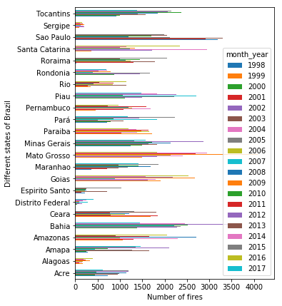

```python
# plotting a simple horizontal bar chart for the state and fires recorded in each year
brazil_fires.loc[:, '1998' : '2017'].plot(figsize = (5, 7), kind = 'barh')
#setting the x label
plt.xlabel("Number of fires")
#setting the label for the y axis
plt.ylabel("Different states of Brazil")
#displaying the plot
plt.show()
```

It's clear that the above graphs don't do much in the way of analysis, due to sheer volume of data. We'll need more interactive graphs for our purpose.

### 2.1 Fires recorded in each state from 1998 to 2017:

I'm using plotly for this part. Writing a function that automates adding the traces, given the state and name I want the trace to have (In this case, the name of the state in question):

```python
#creating a function to add traces for plotly graph automatically
def trace_by_state(state, name):
    #making a new temporary dataframe from the existing one to use in this function
    df = pd.DataFrame(brazil_fires.loc[:, '1998':'2017'])
    #adding the trace
    fig.add_trace(go.Scatter(x = df.columns,
                             y = df.loc[state],
                             name = name,
                             mode="lines"))
    #setting the labels for the X axis and the Y axis
    fig.update_layout(
        xaxis_title = "Years (1998 to 2017)",
        yaxis_title = "Number of Fires recorded")
```

Plotting the graph:

```python
#instantiating the graph_objects function
fig = go.Figure()
#calling the function made above with all the states as parameters to automatically add their traces
trace_by_state('Acre', 'Acre')
trace_by_state('Alagoas', 'Alagoas')
trace_by_state('Amapa', 'Amapa')
trace_by_state('Amazonas', 'Amazonas')
trace_by_state('Bahia', 'Bahia')
trace_by_state('Distrito Federal', 'Distrito Federal')
trace_by_state('Espirito Santo', 'Espirito Santo')
trace_by_state('Goias', 'Goias')
trace_by_state('Maranhao', 'Maranhao')
trace_by_state('Mato Grosso', 'Mato Grosso')
trace_by_state('Minas Gerais', 'Minas Gerais')
trace_by_state('Paraiba', 'Paraiba')
trace_by_state('Pará','Pará' )
trace_by_state('Pernambuco', 'Pernambuco')
trace_by_state('Piau', 'Piau')
trace_by_state('Rio', 'Rio')
trace_by_state('Rondonia', 'Rondonia')
trace_by_state('Roraima', 'Roraima')
trace_by_state('Santa Catarina', 'Santa Catarina')
trace_by_state('Sao Paulo', 'Sao Paulo')
trace_by_state('Sergipe', 'Sergipe')
trace_by_state('Tocantins', 'Tocantins')
#using updatemenus to add buttons for the interactive graph
fig.update_layout(
    updatemenus=[
        go.layout.Updatemenu(
            active=0,
            buttons=list([
                dict(label="Acre",
                     method="update",
                     args=[{"visible": [True, False, False, False, False, False, False,False,False,False,False,False,False,False,False,False,False,False,False,False,False,False,False,False]},
                           {"title": "Total Fires Recorded Each Year for Acre"}]),
                dict(label="Alagoas",
                     method="update",
                     args=[{"visible": [False, True, False, False, False, False,False,False,False,False,False,False,False,False,False,False,False,False,False,False,False,False,False,False]},
                           {"title": "Total Fires Recorded Each Year for Alagoas"}]),
                dict(label="Amapa",
                     method="update",
                     args=[{"visible": [False, False, True, False, False, False,False,False,False,False,False,False,False,False,False,False,False,False,False,False,False,False,False,False]},
                           {"title": "Total Fires Recorded Each Year for Amapa"}]),
                dict(label="Amazonas",
                     method="update",
                     args=[{"visible": [False, False, False, True, False, False,False,False,False,False,False,False,False,False,False,False,False,False,False,False,False,False,False,False]},
                           {"title": "Total Fires Recorded Each Year for Amazonas"}]),
                dict(label="Bahia",
                     method="update",
                     args=[{"visible": [False, False, False, False, True, False,False,False,False,False,False,False,False,False,False,False,False,False,False,False,False,False,False,False]},
                           {"title": "Total Fires Recorded Each Year for Bahia"}]),
                 dict(label="Distrito Federal",
                     method="update",
                     args=[{"visible": [False, False, False, False, False, True,False,False,False,False,False,False,False,False,False,False,False,False,False,False,False,False,False,False]},
                           {"title": "Total Fires Recorded Each Year for Distrito Federal"}]),
                 dict(label="Espirito Santo",
                     method="update",
                     args=[{"visible": [False, False, False, False, False, False,True,False,False,False,False,False,False,False,False,False,False,False,False,False,False,False,False,False]},
                           {"title": "Total Fires Recorded Each Year for Espirito Santo"}]),
                 dict(label="Goias",
                     method="update",
                     args=[{"visible": [False, False, False, False, False, False,False,True,False,False,False,False,False,False,False,False,False,False,False,False,False,False,False,False]},
                           {"title": "Total Fires Recorded Each Year for Goias"}]),
                 dict(label="Maranhao",
                     method="update",
                     args=[{"visible": [False, False, False, False, False, False,False,False,True,False,False,False,False,False,False,False,False,False,False,False,False,False,False,False]},
                           {"title": "Total Fires Recorded Each Year for Maranhao"}]),
                 dict(label="Mato Grosso",
                     method="update",
                     args=[{"visible": [False, False, False, False, False, False,False,False,False,True,False,False,False,False,False,False,False,False,False,False,False,False,False,False]},
                           {"title": "Total Fires Recorded Each Year for Mato Grosso"}]),
                dict(label="Minas Gerais",
                     method="update",
                     args=[{"visible": [False, False, False, False, False, False,False,False,False,False,True,False,False,False,False,False,False,False,False,False,False,False,False,False]},
                           {"title": "Total Fires Recorded Each Year for Minas Gerais"}]),
                dict(label="Paraiba",
                     method="update",
                     args=[{"visible": [False, False, False, False, False, False,False,False,False,False,False,True,False,False,False,False,False,False,False,False,False,False,False,False]},
                           {"title": "Total Fires Recorded Each Year for Paraiba"}]),
                dict(label="Pará",
                     method="update",
                     args=[{"visible": [False, False, False, False, False, False,False,False,False,False,False,False,True,False,False,False,False,False,False,False,False,False,False,False]},
                           {"title": "Total Fires Recorded Each Year for Pará"}]),
                dict(label="Pernambuco",
                     method="update",
                     args=[{"visible": [False, False, False, False, False, False,False,False,False,False,False,False,False,True,False,False,False,False,False,False,False,False,False,False]},
                           {"title": "Total Fires Recorded Each Year for Pernambuco"}]),
                 dict(label="Piau",
                     method="update",
                     args=[{"visible": [False, False, False, False, False, False,False,False,False,False,False,False,False,False,True,False,False,False,False,False,False,False,False,False]},
                           {"title": "Total Fires Recorded Each Year for Piau"}]),
                 dict(label="Rio",
                     method="update",
                     args=[{"visible": [False, False, False, False, False, False,False,False,False,False,False,False,False,False,False,True,False,False,False,False,False,False,False,False]},
                           {"title": "Total Fires Recorded Each Year for Rondonia"}]),
                 dict(label="Rondonia",
                     method="update",
                     args=[{"visible": [False, False, False, False, False, False,False,False,False,False,False,False,False,False,False,False,True,False,False,False,False,False,False,False]},
                           {"title": "Total Fires Recorded Each Year for Rio"}]),
                 dict(label="Roraima",
                     method="update",
                     args=[{"visible": [False, False, False, False, False, False,False,False,False,False,False,False,False,False,False,False,False,True,False,False,False,False,False,False]},
                           {"title": "Total Fires Recorded Each Year for Roraima"}]),
                 dict(label="Santa Catarina",
                     method="update",
                     args=[{"visible": [False, False, False, False, False, False,False,False,False,False,False,False,False,False,False,False,False,False,True,False,False,False,False,False]},
                           {"title": "Total Fires Recorded Each Year for Santa Catarina"}]),
                 dict(label="Sao Paulo",
                     method="update",
                     args=[{"visible": [False, False, False, False, False, False,False,False,False,False,False,False,False,False,False,False,False,False,False,True,False,False,False,False]},
                           {"title": "Total Fires Recorded Each Year for Sao Paulo"}]),
                dict(label="Sergipe",
                     method="update",
                     args=[{"visible": [False, False, False, False, False, False,False,False,False,False,False,False,False,False,False,False,False,False,False,False,True,False,False,False]},
                           {"title": "Total Fires Recorded Each Year for Sergipe"}]),
                dict(label="Tocantins",
                     method="update",
                     args=[{"visible": [False, False, False, False, False, False,False,False,False,False,False,False,False,False,False,False,False,False,False,False,False,True,False,False]},
                           {"title": "Total Fires Recorded Each Year for Tocantins"}]),
                dict(label="All",
                     method="update",
                     args=[{"visible": [True]*23},
                           {"title": "Total Fires Recorded Each Year for  All States"}]),
                dict(label="Reset",
                     method="update",
                     args=[{"visible": [False]*23},
                           {"title": "Total Fires Recorded Each Year for  All States"}]),]),)])
# Set title for the plot
fig.update_layout(title_text="Total Number of Fires Recorded Each Year for Every State")
#Displaying the plot
fig.show()
```

[interactive chart not shown]

On a closer look at the graphs, we notice that three states - Bahia, Mato Grosso, and Sao Paulo - consistently show a higher number of wildfires. These states have had fires exceeding the number of 3000 multiple times and have even reached the 4000 mark. We'll take a closer look at these states by breakding down the year into a month to month span in a later section.

Sergipe and Distrito Federal show a consistently lower number of fires, though Sergipe has not been able to maintain the low of 17 that forest fires reached in 2000, with numbers growing by almost 2200% in three years to show 403 in the year 2003. Its last recorded observation stands at 75, after decreasing in half from 2016's recorded number of 152. Distrito Federal has been seeing increases as well, changing from a low of 46 in 1999 to a high of 505 in 2010.

#### Plotting a pie chart to see the shares each state has in the total forest fires recorded from 1998 to 2017:

```python
df_totalfires = pd.DataFrame(brazil_fires.loc[:, '1998': '2017'])
df_totalfires['total fires'] = df_totalfires.sum(axis = 1)
fig_pie = go.Figure()
colors = ['bisque', 'darkorange', 'tan', 'indianred', 'coral', 'chocolate', 'saddlebrown', 'gold', 'khaki', 'yellow', 'darkolivegreen', 'lawngreen', 'lime', 'mintcream', 'darkslategray', 'dodgerblue', 'navy', 'darkorchid', 'fuchsia', 'mediumvioletred', 'pink', 'honeydew', 'darkgray']
fig_pie.add_trace(go.Pie(
    labels = df_totalfires.index,
    values = df_totalfires['total fires']

)
)
fig_pie.show()
```

[interactive chart not shown]

This confirms it - bahia, Mato Grosso and Sao Paulo are thus the states at most risk when it comes to wildfire season. Just those three states cover almost a quarter of the chart! Bahia has a huge anount of vegetation, comprising of the Atlantic Forest, the and multiple coasts and bays, including the Bay of All Saints. Sao Paulo also contains a sizeable chunk of the Atlantic Forest.

Distrito Federal, Alagoas, Espirito Santo,and Sergipe, albeit seeing an increase in count themselves, are the ones at the least risk, likely owing to their small sizes - Distrito Federal is the smallest Brazilian federal unit.

### 2.2 Looking at the years where Bahia, Mato Grosso and Sao Paulo displayed the highest number of fires:

Writing a function that takes as inputs the state, the months I want studied and the name I want the trace to have (the name of the state in this case):

```python
def fires_breakdown_trace(state, start_month, end_month, name):
    #creating a temporary data frame with the values we require for this function
    df_month = pd.DataFrame(brazil_fires.loc[: , start_month : end_month])
    #adding the traces
    fig1.add_trace(go.Scatter(x = df_month.columns,
                             y = df_month.loc[state],
                             name = name,
                             mode="lines"))
    #setting the x and y axis labels
    fig1.update_layout(
    xaxis_title = "Months",
    yaxis_title = "Number of fires recorded"
    )
```

#### Bahia - 2012 and 2016 - Month by Month Study:

Plotting the graphs for Bahia:

```python
#instantiating the graph_objects method
fig1 = go.Figure()

#calling the function made earlier on Bahia
fires_breakdown_trace('Bahia', 'January2012', 'December2012', 'Bahia')
fires_breakdown_trace('Bahia', 'January2016', 'December2016', 'Bahia')

#creating the buttons for the interactive plot using updatemenus
fig1.update_layout(
    updatemenus = [
        go.layout.Updatemenu(
            active = 0,
            buttons = list([
                dict(label = "Bahia - 2012 Fires",
                     method = "update",
                     args = [{"visible" : [True, False, False, False]},
                             {"title": "Number of Wildfires every Month in 2012 for Bahia"}]),
                   dict(label = "Bahia - 2016 Fires",
                     method = "update",
                     args = [{"visible" : [False, True, False, False]},
                             {"title": "Number of Wildfires every Month in 2016 for Bahia"}]),
                dict(label = "Both 2012 and 2016 Fires",
                     method = "update",
                     args = [{"visible" : [True, True]},
                             {"title": "Number of Wildfires every Month for 2012 and 2016 in Bahia"}]),
                 dict(label = "Reset",
                     method = "update",
                     args = [{"visible" : [False, False]},
                             {"title": "Number of Wildfires every Month for 2012 and 2016 in Bahia"}]),


            ])

        )
    ]
)


#displaying the plot
fig1.show()
```

[interactive chart not shown]

#### Mato Grosso - Fires in 2003 and 2009:

```python
fig1 = go.Figure()
#calling the function made earlier on Mato Grosso
fires_breakdown_trace('Mato Grosso', 'January2003', 'December2003', 'Mato Grosso')
fires_breakdown_trace('Mato Grosso', 'January2009', 'December2009', 'Mato Grosso')

#creating the buttons
fig1.update_layout(
    updatemenus = [
        go.layout.Updatemenu(
            active = 0,
            buttons = list([
                dict(label = "Mato Grosso - Fires in 2003",
                     method = "update",
                     args = [{"visible" : [True, False, False, False]},
                             {"title": "Number of Wildfires every Month in 2003 for Mato Grosso"}]),
                   dict(label = "Mato Grosso - Fires in 2009",
                     method = "update",
                     args = [{"visible" : [False, True, False, False]},
                             {"title": "Number of Wildfires every Month in 2009 for Mato Grosso"}]),
                dict(label = "Both 2003 and 2009 Fires",
                     method = "update",
                     args = [{"visible" : [True, True]},
                             {"title": "Number of Wildfires every Month for 2003 and 2009 in Mato Grosso"}]),
                 dict(label = "Reset",
                     method = "update",
                     args = [{"visible" : [False, False]},
                             {"title": "Number of Wildfires every Month for 2003 and 2009"}]),


            ])

        )
    ]
)

fig1.show()
```

[interactive chart not shown]